# The Effect Inflation Dataset

## 4.5 Specific Observations Included

Machine-readable result-level file: plot3_preregistered_results.tsv (CSV mirror: plot3_preregistered_results.csv).

Machine-readable display-table file: plot3_preregistered_display_table.tsv

The specific-observation layer has `3,546` plotted preregistered result/project dots. Admission now uses the relaxed planned-result rule plus one-dot-per-paper/project median collapse where a source exposes multiple planned outcomes, treatment arms, sites, or archive components. Political-science extraction packages retain their component contrasts in the audit files, but the plotted political-science layer is collapsed to paper/project medians. For plotting, rows are collapsed by broad field rather than raw source family. The result-level CSV still records source citation, result label, journal, `D`, `N`, and the source row number for auditability. Support calls are retained in the CSV as metadata but are not used for admission or visual encoding, because they mostly track the preregistered decision rule rather than a distinct effect-size concept.

| Field | Rows | Source families | Median D | Median N |
| --- | --- | --- | --- | --- |
| Clinical medicine | 3,149 | 1 | 0.251 | 246 |
| Psychology/health | 258 | 9 | 0.385 | 225 |
| Economics/finance | 56 | 2 | 0.076 | 1,979 |
| Political science | 55 | 36 | 0.093 | 2,386 |
| Preclinical biology | 23 | 1 | 0.929 | 13 |
| Education | 3 | 2 | 0.074 | 2,081 |
| Business | 1 | 1 | 1.358 | 83 |
| Sociology/criminology | 1 | 1 | 0.241 | 400 |

| Field | Source | Specific paper/result | Journal | D/N |
| --- | --- | --- | --- | --- |
| Business | SCORE/COS preregistration-indicated original papers (Tyner et al. 2026) | 2018 - When Wanting To Be Fair Is Not Enough: The Effects Of Depletion And Self-Appraisal | Journal of Management | 1.358 / 83 |
| Clinical medicine | ClinicalTrials.gov phase-2+ primary randomized registry rows (Du 2024) | Percentage of Patients Who Developed Cytomegalovirus (CMV) Disease up to Month 12 Post-tra | ClinicalTrials.gov | 0.412 / 326 |
| Clinical medicine | ClinicalTrials.gov phase-2+ primary randomized registry rows (Du 2024) | Percent Change in Low Density Lipoprotein-Cholesterol (LDL-C) at Study Endpoint After Six | ClinicalTrials.gov | 0.265 / 618 |
| Clinical medicine | ClinicalTrials.gov phase-2+ primary randomized registry rows (Du 2024) | Geometric Mean Titer (GMT) of Anti-HPV 6, 11, 16 , 18 at Day 1 and Month 7 (1 Month After | ClinicalTrials.gov | 0.160 / 600 |
| Clinical medicine | ClinicalTrials.gov phase-2+ primary randomized registry rows (Du 2024) | Hemoglobin A1C (A1C) at Week 18 | ClinicalTrials.gov | 0.398 / 273 |
| Clinical medicine | ClinicalTrials.gov phase-2+ primary randomized registry rows (Du 2024) | Change in the Neuropsychiatric Inventory (NPI) Agitation/Aggression Domain Score From Day | ClinicalTrials.gov | 0.444 / 220 |
| Clinical medicine | ClinicalTrials.gov phase-2+ primary randomized registry rows (Du 2024) | Relapse-free Survival Rates at 2.4 Years | ClinicalTrials.gov | 0.262 / 633 |
| Clinical medicine | ClinicalTrials.gov phase-2+ primary randomized registry rows (Du 2024) | 15-Item Word List Delayed Recall | ClinicalTrials.gov | 0.296 / 175 |
| Clinical medicine | ClinicalTrials.gov phase-2+ primary randomized registry rows (Du 2024) | Change From Baseline at 18 Month Endpoint in Lumbar Spine Bone Mineral Density (BMD) | ClinicalTrials.gov | 0.318 / 428 |
| Clinical medicine | ClinicalTrials.gov phase-2+ primary randomized registry rows (Du 2024) | Change From Baseline in Hepatitis B Virus (HBV) DNA by Polymerase Chain Reaction (PCR) at | ClinicalTrials.gov | 0.557 / 195 |
| Clinical medicine | ClinicalTrials.gov phase-2+ primary randomized registry rows (Du 2024) | Mean Change in Hemoglobin Concentration (g/dL) From Baseline to Evaluation Period | ClinicalTrials.gov | 0.440 / 313 |
| Clinical medicine | ClinicalTrials.gov phase-2+ primary randomized registry rows (Du 2024) | Percentage of Participants Achieving a ≥ 75% Improvement in Psoriasis Area and Severity In | ClinicalTrials.gov | 0.536 / 211 |
| Clinical medicine | ClinicalTrials.gov phase-2+ primary randomized registry rows (Du 2024) | Change From Baseline in Clinical Global Impression of Change (CGI-C) Score at 12 Weeks | ClinicalTrials.gov | 0.556 / 196 |
| Clinical medicine | ClinicalTrials.gov phase-2+ primary randomized registry rows (Du 2024) | Number of Responders With a Reduction of Signs and Symptoms of Ankylosing Spondylitis (AS) | ClinicalTrials.gov | 0.371 / 315 |
| Clinical medicine | ClinicalTrials.gov phase-2+ primary randomized registry rows (Du 2024) | Treatment Period I: Change From Baseline in Absolute Area of Visceral Adipose Tissue (VAT) | ClinicalTrials.gov | 0.364 / 326 |
| Clinical medicine | ClinicalTrials.gov phase-2+ primary randomized registry rows (Du 2024) | Kaplan-Meier Estimates for Progression-free Survival (PFS) Based on Independent Response R | ClinicalTrials.gov | 0.360 / 335 |
| Clinical medicine | ClinicalTrials.gov phase-2+ primary randomized registry rows (Du 2024) | Change From Baseline to the End of the Double-blind Treatment in the BPRS (Brief Psychiatr | ClinicalTrials.gov | 0.292 / 180 |
| Clinical medicine | ClinicalTrials.gov phase-2+ primary randomized registry rows (Du 2024) | Number of Participants With New Vertebral Fractures | ClinicalTrials.gov | 0.088 / 7,808 |
| Clinical medicine | ClinicalTrials.gov phase-2+ primary randomized registry rows (Du 2024) | Change From Baseline in Hemoglobin A1C (A1C) at Week 24 | ClinicalTrials.gov | 0.249 / 701 |
| Clinical medicine | ClinicalTrials.gov phase-2+ primary randomized registry rows (Du 2024) | Lumbar Spine Bone Mineral Density Percent Change From Baseline at Month 24 | ClinicalTrials.gov | 0.203 / 1,468 |
| Clinical medicine | ClinicalTrials.gov phase-2+ primary randomized registry rows (Du 2024) | Lumbar Spine Bone Mineral Density Percent Change From Baseline at Month 12 | ClinicalTrials.gov | 0.490 / 252 |
| Clinical medicine | ClinicalTrials.gov phase-2+ primary randomized registry rows (Du 2024) | Occurence of Clinical Rotavirus Disease Caused by the Composite of the Serotypes Contained | ClinicalTrials.gov | 0.182 / 1,312 |
| Clinical medicine | ClinicalTrials.gov phase-2+ primary randomized registry rows (Du 2024) | DB; Adjusted Mean Change From Baseline to Day 197 in Disease Activity Score (DAS) 28 Score | ClinicalTrials.gov | 0.317 / 431 |
| Clinical medicine | ClinicalTrials.gov phase-2+ primary randomized registry rows (Du 2024) | Lumbar Spine Bone Mineral Density Percent Change From Baseline at Month 24 | ClinicalTrials.gov | 0.427 / 332 |
| Clinical medicine | ClinicalTrials.gov phase-2+ primary randomized registry rows (Du 2024) | Percentage of Participants With Serum Hepatitis B Virus (HBV) Deoxyribonucleic Acid (DNA) | ClinicalTrials.gov | 0.500 / 173 |
| Clinical medicine | ClinicalTrials.gov phase-2+ primary randomized registry rows (Du 2024) | Percentage of Participants With Depressive Recurrence After Time (t) in Days | ClinicalTrials.gov | 0.290 / 514 |
| Clinical medicine | ClinicalTrials.gov phase-2+ primary randomized registry rows (Du 2024) | Mean Change in the Montgomery Åsberg Depression Rating Scale (MADRS) | ClinicalTrials.gov | 0.352 / 349 |
| Clinical medicine | ClinicalTrials.gov phase-2+ primary randomized registry rows (Du 2024) | Percent Change From Baseline Lumbar Spine Bone Mineral Density (BMD) at Month 12, ITT Popu | ClinicalTrials.gov | 0.651 / 143 |
| Clinical medicine | ClinicalTrials.gov phase-2+ primary randomized registry rows (Du 2024) | Change From Baseline in A1C at Week 24 | ClinicalTrials.gov | 0.313 / 441 |
| Clinical medicine | ClinicalTrials.gov phase-2+ primary randomized registry rows (Du 2024) | Disease Remission | ClinicalTrials.gov | 0.469 / 197 |

[output cut: 3516 more lines]

### 4.5.1 What Is Still Missing

- The included core now combines Registered Reports, PSA-CR001 and PSA-CR002 pooled/preregistered hypothesis rows, PSA004 pooled Gettier evidence, ManyBabies 1 and ManyBabies 1 Bilingual, ManyClasses 1, pooled EGAP Metaketa I/III/IV PAP rows, the Schäfer/Schwarz preregistered key-effect sample, SCORE preregistration-indicated paper-level rows, van den Akker matched preregistered-result paper medians, and RPCB preclinical Registered Report paper medians.
- The expanded considered-but-not-included list now names the major local preregistered-like sidecars separately: enriched TESS study-page extraction queue, concrete AEA/EGAP/Dataverse/DIME/SCORE political-science worklist, Many Labs, RRR pair rows, PSA replication rows, Transparent Psi, Allen/Mehler RR support-rate evidence, ManyBabies 3, ManyBabies 4, ManyClasses 2, EGAP Metaketa I/III/IV native/component ATE rows, ERN/Pe, self-control fMRI, Twomey, Linden, Protzko, AACT/ClinicalTrials.gov, CliniFact, Brodeur preregistered/PAP economics table tests, Nordic trial reporting, FReD, communication privacy, retrieval-extinction rats, and the larger van den Akker selective-hypothesis-reporting corpus.
- Most of those extra local sources are out because they are already Plot 1 replication-pair evidence, registry metadata rather than analytic preregistration, publication-linkage metadata without effect statistics, document/native-metric payloads without a compact D/N result table, or extracted table-test corpora without a focal/main-result selector.
- The considered list is still a working audit, not a claim that every preregistered-like source on the web has been exhausted.

## 4.6 Current Files

- Preregistered hypotheses corpus: table_40_preregistered_hypotheses_scheel_2021_psa_cr001_corpus.csv
- Added PSA-CR001 pooled rows: table_41_added_preregistered_rows_from_psa_cr001_dorison_et_al_2022.csv
- Schäfer/Schwarz preregistered and non-preregistered parsed paper rows: candidate_d_n_papers.csv
- Source-family admission audit: plot3_preregistered_source_catalog.csv
- Normalized plot rows: plot3_preregistered_results.csv
- Sensitivity sidecar rows: plot3_preregistered_sensitivity_sidecar_rows.csv
- Cleaner ClinicalTrials.gov sub-sidecar rows: plot3_ctgov_phase2plus_primary_randomized_sidecar_rows.csv
- ClinicalTrials.gov API registered outcome-analysis rows: plot3_ctgov_api_registered_outcome_ratio_event_rows.csv.gz
- ClinicalTrials.gov API one-trial median rows: plot3_ctgov_api_registered_trial_medians.csv
- RPCB preclinical Registered Report medians: plot3_rpcb_preclinical_paper_level_candidates.csv
- Generated table fragments: table_40_preregistered_hypotheses_scheel_2021_psa_cr001_corpus.qmd and table_41_added_preregistered_rows_from_psa_cr001_dorison_et_al_2022.qmd

## 4.7 What Is Already in Hand

The current preregistered corpus is not hypothetical. It already contains:

- the Scheel / Schijen / Lakens Registered Reports extraction,
- the pooled PSA-CR001 confirmatory rows,
- the Schäfer/Schwarz preregistered psychology key-effect sample,
- the SCORE and van den Akker paper-median expansions,
- the RPCB preclinical Registered Report medians,
- and an explicit source-family table documenting comparator, retraction, registration-only, missing-payload, native-metric, and double-counting exclusions.

So Plot 3 is no longer blocked on first presentation. The source audit now also names the local preregistered-like families that should not silently disappear: Many Labs, RRR pair rows, PSA replication rows, Transparent Psi, Allen/Mehler RR support-rate evidence, ManyBabies 3, ManyBabies 4, ManyClasses 2, EGAP Metaketa I/III/IV native ATE rows, ERN/Pe, self-control fMRI, Twomey, Linden, Protzko, AACT/ClinicalTrials.gov, CliniFact, Brodeur preregistered/PAP economics table tests, Nordic trial reporting, FReD, communication privacy, retrieval-extinction rats, and the van den Akker preregistration-in-practice and selective-hypothesis-reporting corpora. The remaining work is policy cleanup: deciding whether any registry-only biomedical rows, preregistered economics table-test rows, lab-level RRR rows, native field-experiment estimates, or other preregistered-like sidecars should get separate lanes rather than entering this confirmatory-result layer.

## 4.8 What The First Version Should Show

The first preregistered-results plot does one narrow thing:

- place preregistered confirmatory results on the same `D`/`N` axes as the published-endpoint and replication corpora,
- keep Scheel-style Registered Reports, PSA-CR001 rows, and support-not-coded preregistered psychology key effects visually distinguishable,
- and make clear that these are neither original/replication pairs nor a complete registry of all preregistered science.

The key point is comparison, not exhaustiveness. Plot 3 should show what precommitted confirmatory results look like on the same scale as the other two plotted worlds.

# 5 Plot 4 — All-Source `D`/`N` Dump

Plot 4 now exists as a first-pass answer to the “show me everything recoverable” request. It is deliberately less clean than Plot 1, Plot 2, or Plot 3: the purpose is to show the current `D`/`N` surface across all normalized layers, not to create one exchangeable statistical sample.

## 5.1 Figure

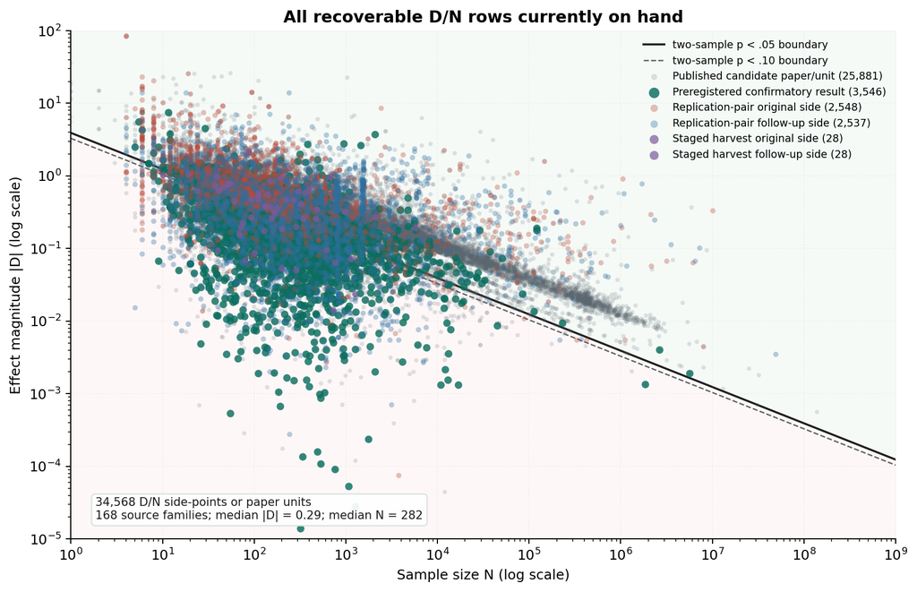

All recoverable positive D/N rows currently on hand, combining published candidate rows, replication-pair sides, preregistered results, and any staged D/N sidecar rows.

## 5.2 Inclusion Criteria

The current first-pass rule is intentionally simple:

- include every positive-`D`, positive-`N` row from the normalized top-level layers,
- split live replication pairs into original-side and follow-up-side points,
- include paper-level candidate rows from the published-corpus file,
- include preregistered confirmatory rows from Plot 3,
- include non-promoted staged rows only when that staged artifact already carries a usable `D` and `N`,
- exclude native-metric-only rows until a sidecar policy exists.

This makes Plot 4 a surface map. It is useful for inspection and sanity checking, but it should not be used as an inferential denominator without further deduplication and source-family weighting.

## 5.3 Corpora Considered

Machine-readable catalog: plot4_all_source_dump_catalog.csv

Machine-readable normalized row dump: plot4_all_source_dn_rows.csv

Plot 4 now has a first-pass all-source D/N surface map with `34,568` positive-D/N points. It is intentionally a descriptive dump, not a clean inferential layer.

This first table is the feeder-corpus admission audit: what was considered, what it is, why it is in or out of the all-source dump, and how many observations made it in.

| Corpus considered | What it is | Why in/out | # obs in |
| --- | --- | --- | --- |
| Published-paper endpoint candidate corpus | Paper/unit-level published endpoint candidates with recoverable D and N. | included: include every candidate paper/study unit with positive D and N from the current candidate paper-level file; mixes published-original candidates, comparator-only rows, and other paper-level c… | 25,881 |
| Replication-pairs live corpus | Original and follow-up sides from the live replication-pair corpus. | included: split each live endpoint pair into original-side and follow-up-side D/N points; side-level points intentionally duplicate pair membership; this layer is descriptive, not an inferential paire… | 5,085 |
| Preregistered-results tables | Normalized preregistered confirmatory result rows from Plot 3. | included: include each normalized preregistered confirmatory D/N result from Plot 3; small curated layer; not an exhaustive registry of preregistered science | 3,546 |
| Staged replication harvest artifacts | Non-promoted staged harvest rows that already expose positive D and N for a side. | sidecar included: include non-promoted staged rows only when a positive D and N are already present for a side; most staged files are roster-only, native-metric, or otherwise D-blocked and therefore r… | 56 |
| Promoted harvest pair tables | Source-specific promoted harvest outputs already folded into the live replication-pair table. | not separately included: not separately loaded; promoted rows are already folded into the live replication-pairs corpus above, so direct inclusion would duplicate them | 0 |

## 5.4 Specific Observations Included

Machine-readable row-level file: plot4_all_source_dn_rows.csv

The specific-row layer has `34,568` positive-`D`/`N` points. It records source family, source file, row unit, row label, point id, source layer, side, `D`, `N`, and publication-boundary flags.

Layer summary:

| Source layer | Points | Source families | Median D | Median N |
| --- | --- | --- | --- | --- |
| published_candidate_paper | 25,881 | 30 | 0.28 | 322 |
| preregistered_confirmatory_result | 3,546 | 47 | 0.25 | 251 |
| replication_pair_original | 2,548 | 91 | 0.59 | 120 |
| replication_pair_followup | 2,537 | 91 | 0.29 | 290 |
| staged_harvest_followup | 28 | 1 | 0.27 | 323 |
| staged_harvest_original | 28 | 1 | 0.51 | 72 |

Largest specific source families in the dump:

| Source layer | Source family | Points |
| --- | --- | --- |
| published_candidate_paper | ctgov_finer_grained_kg | 7,722 |
| published_candidate_paper | gwas_catalog | 6,711 |
| published_candidate_paper | score_cos_claims | 3,193 |
| preregistered_confirmatory_result | ClinicalTrials.gov phase-2+ primary randomized registry rows | 3,149 |
| published_candidate_paper | metabus_open_bosco | 1,999 |
| replication_pair_original | FReD filtered pair table | 856 |
| replication_pair_followup | FReD filtered pair table | 848 |
| published_candidate_paper | forrt_fred | 796 |
| published_candidate_paper | schaefer_schwarz_2019_without_prereg | 682 |
| published_candidate_paper | button_nord_neuroscience | 649 |
| published_candidate_paper | motyl_2017_critical_tests | 540 |
| published_candidate_paper | olsson_sundell_2023_social_interventions | 476 |
| published_candidate_paper | kuhberger_2014_main_results | 472 |
| published_candidate_paper | replication_pair_originals_bridge | 431 |
| published_candidate_paper | clinifact_published_primary_pairs | 339 |

### 5.4.1 What Is Still Missing

- Plot 4 now has a practical side-point/paper-unit schema, but it still needs a formal deduplication audit across overlapping source families.
- Native-metric rows are still excluded from this D/N-only figure; they need either a parallel dump or explicit facet policy.
- The all-source layer intentionally mixes paper-level candidate rows with pair-side rows, so it should not be read as a single exchangeable statistical sample.

## 5.5 Intended Scope

Plot 4 is not a clean inferential layer like Plot 1. It is a **surface map** of every recoverable `D` and `N` row from all checked source families, whether or not the row is good enough for the cleaner publication-boundary or replication analyses.

That means it could potentially include:

- original and replication sides from the live pair corpus,
- paper-level published-original rows,
- preregistered confirmatory rows,
- non-promoted staged rows that already carry `D` and `N`,
- and later, perhaps, a native-metric sidecar for rows that cannot honestly be forced onto `D`.

## 5.6 Candidate Feeder Files

The closest existing feeder files are:

- replication_pairs_all_on_hand.csv
- candidate_d_n_papers.csv
- table_40_preregistered_hypotheses_scheel_2021_psa_cr001_corpus.csv
- table_41_added_preregistered_rows_from_psa_cr001_dorison_et_al_2022.csv
- the staged and promoted harvest directories under data/derived/replication_pairs/harvest
- normalized all-source rows: plot4_all_source_dn_rows.csv

## 5.7 What Still Has To Be Decided

Before Plot 4 becomes analytically usable, the project needs to decide:

- how to deduplicate source families that appear in multiple upstream layers,
- whether the paper-level candidate rows should be split into published-original, comparator-only, and non-focal panels,
- whether staged-but-not-promoted rows should remain in the same visual layer or become a sidecar,
- and whether native-metric rows should be excluded, faceted, or carried in a parallel dump.

Those decisions matter because Plot 4 is the most ambitious aggregation layer and therefore the one most likely to blur distinctions if read too aggressively.

# 6 Relation to the Main Manuscript

The main manuscript asks the substantive question about effect inflation. This companion paper now plays a different role: it is the plot-oriented technical dossier behind the evidence base.

The current division of labor is:

- the main paper makes the empirical and conceptual case,
- this data paper documents how each plot is built and what still blocks the next one,
- the generated appendix archive preserves unsorted source-family detail until it can be promoted into plot-specific sections.

# 7 Remaining Gaps

The next high-value improvements are now plot-specific:

1. give Plot 2 a source-family audit structure as strong as Plot 1,
2. expand the Plot 3 considered-source sweep and build a formal preregistered-source evidence inventory,
3. formalize Plot 4 deduplication rules before using the all-source dump inferentially,
4. formalize a native-metric lane for strong same-endpoint rows that are `D`-blocked,
5. continue parser work on the high-priority staged sources already sitting on the replication worklist,
6. sort the old Appendix A-E material into the plot-specific audits or retire it to conceptual appendix notes.

# 8 Conclusion

The Effect Inflation Dataset is no longer just “the replication-pairs table.” It is becoming a family of related plot layers with different standards of cleanliness and different inclusion rules.

That is the right way to think about the project:

- Plot 1 is the cleanest replication-comparison layer.
- Plot 2 is the current published-paper surface.
- Plot 3 is the preregistered comparison layer.
- Plot 4 is the first-pass everything-we-can-recover `D`/`N` layer.

Keeping those layers distinct is how the project can scale without turning into one opaque dump.

# 9 Appendix Integration Queue

The old Appendix A-E bundle is no longer rendered inline because it mixes conceptual material, plot documentation, source extraction notes, and retired figures. The generated archive remains at `docs/_generated/data_appendices.qmd` for extraction, but reader-facing material should move into the plot sections above.

| Old appendix material | Target home | Current action |
| --- | --- | --- |
| Real-distribution and field-rate background | Main manuscript background or a separate field-benchmark appendix | Keep out of this dataset paper until the source table is separated from the argument text. |
| Large-effect exceptions and interpretation notes | Main manuscript conceptual appendix | Do not treat as dataset construction material. |
| Hellscape examples and failure-mode catalog | Main manuscript examples or introduction notes | Preserve as argument support, not as a source-audit appendix. |
| Replication-pair extraction notes | Plot 1 replication-pair source audit | Extract any remaining source details into the Plot 1 catalog. |
| Statcheck, Brodeur, Havranek, Gechert, and related published-endpoint notes | Plot 2 published-paper source audit | Convert prose into source-family rows with citation and inclusion status. |
| Scheel, Dorison, and other preregistered-source notes | Plot 3 preregistered-results audit | Expand the considered-source inventory and record why each source is included or blocked. |
| Cochrane, AACT, and other medicine/native-metric material | Plot 4 sidecar or a medicine-specific supplement | Keep separate from the current shared-`D`/`N` dump until native-metric rules are explicit. |

## References

Ackerman, Joshua M., Christopher C. Nocera, and John A. Bargh. 2010. “Incidental Haptic Sensations Influence Social Judgments and Decisions.” *Science* 328 (5986): 1712–15. https://doi.org/10.1126/science.1189993.

Adema, Joost, Cevat Giray Aksoy, Panu Poutvaara, et al. 2025. “Replication Package for Adema Et Al. PNAS (2025).” Zenodo. https://doi.org/10.5281/zenodo.15322600.

Afrouzi, Hassan, Carolina Arteaga, and Emily Weisburst. 2024. “Replication Data for: Is It the Message or the Messenger? Examining Movement in Immigration Beliefs.” Harvard Dataverse. https://doi.org/10.7910/DVN/8DM8KG.

Ahmed, Firoz, Roland Hodler, and Asad Islam. 2023. “Replication Package for: Partisan Effects of Information Campaigns in Competitive Authoritarian Elections: Evidence from Bangladesh.” Zenodo. https://doi.org/10.5281/zenodo.10059860.

Akker, Olmo R. van den, Marcel A. L. M. van Assen, Manon Enting, Myrthe de Jonge, How Hwee Ong, Franziska Rueffer, Martijn Schoenmakers, Andrea H. Stoevenbelt, Jelte M. Wicherts, and Marjan Bakker. 2023. “Selective Hypothesis Reporting in Psychology: Comparing Preregistrations and Corresponding Publications.” *Advances in Methods and Practices in Psychological Science* 6 (3): 25152459231187988. https://doi.org/10.1177/25152459231187988.

Allakulov, U., S. Cocciolo, B. Das, M. A. Habib, L. Rambjer, and Anna Louise Tompsett. 2023. “Replication Data for: Transparency, Governance, and Water and Sanitation: Experimental Evidence from Schools in Rural Bangladesh.” Harvard Dataverse. https://doi.org/10.7910/DVN/U9I4Z2.

Allen, Christopher, and David M. A. Mehler. 2019. “Open Science Challenges, Benefits and Tips in Early Career and Beyond.” *PLOS Biology* 17 (5): e3000246. https://doi.org/10.1371/journal.pbio.3000246.

Alogna, Vincenzo K., Michelle K. Attaya, Paul Aucoin, Stepan Bahnik, Samuel Birch, Angela R. Birt, et al. 2014. “Registered Replication Report: Schooler and Engstler-Schooler (1990).” *Perspectives on Psychological Science* 9 (5): 556–78. https://doi.org/10.1177/1745691614545653.

Al-Ubaydli, Omar, John A. List, and Dana L. Suskind. 2017. “What Can We Learn from Experiments? Understanding the Threats to the Scalability of Experimental Results.” *American Economic Review* 107 (5): 282–86. https://doi.org/10.1257/aer.p20171115.

Amaral, Olavo B., Kleber Neves, Ana P. Wasilewska-Sampaio, and Clarissa F. D. Carneiro. 2019. “The Brazilian Reproducibility Initiative.” *eLife* 8: e41602. https://doi.org/10.7554/eLife.41602.

Andersson, Julius J. 2019. “Carbon Taxes and CO2 Emissions: Sweden as a Case Study.” *American Economic Journal: Economic Policy* 11 (4): 1–30. https://doi.org/10.1257/pol.20170144.

Anglemyer, Andrew, Hacsi T Horvath, and Lisa Bero. 2014. “Healthcare Outcomes Assessed with Observational Study Designs Compared with Those Assessed in Randomized Trials.” *Cochrane Database of Systematic Reviews* 2014 (4). https://doi.org/10.1002/14651858.mr000034.pub2.

Arel-Bundock, Vincent, Ryan C. Briggs, Hristos Doucouliagos, Marco M. Avina, and T. D. Stanley. 2026. “Quantitative Political Science Research Is Greatly Underpowered.” *The Journal of Politics*. https://doi.org/10.1086/734279.

Arroyo-Araujo, Maria, Bernhard Voelkl, Clement Laloux, Janja Novak, Bastijn Koopmans, Ann-Marie Waldron, et al. 2022. “Systematic Assessment of the Replicability and Generalizability of Preclinical Findings: Impact of Protocol Harmonization Across Laboratory Sites.” *PLOS Biology*. https://doi.org/10.1371/journal.pbio.3001886.

Arthur, Winfred, Winston Bennett, Pamela S. Edens, and Suzanne T. Bell. 2003. “Effectiveness of Training in Organizations: A Meta-Analysis of Design and Evaluation Features.” *Journal of Applied Psychology* 88 (2): 234–45. https://doi.org/10.1037/0021-9010.88.2.234.

Azevedo, Flavio, Deliah Bolesta, and Leticia Micheli. 2022. “Replication Data for: Does Stereotype Threat Contribute to the Political Knowledge Gender Gap? A Preregistered Replication Study of Ihme and Tausendpfund (2018).” Harvard Dataverse. https://doi.org/10.7910/DVN/ETUUOD.

Bago, Bence, Marton Kovacs, John Protzko, Tamas Nagy, Zoltan Kekecs, et al. 2022. “Situational Factors Shape Moral Judgements in the Trolley Dilemma in Eastern, Southern and Western Countries in a Culturally Diverse Sample.” *Nature Human Behaviour* 6 (6): 880–95. https://doi.org/10.1038/s41562-022-01319-5.

Bajzik, Josef, Tomas Havranek, Zuzana Irsova, and Jiri Schwarz. 2020. “Estimating the Armington Elasticity: The Importance of Study Design and Publication Bias.” *Journal of International Economics* 127: 103383. https://doi.org/10.1016/j.jinteco.2020.103383.

Balakrishnan, Anjana, Paolo A. Palma, Joshua Patenaude, and Lorne Campbell. 2017. “A 4-Study Replication of the Moderating Effects of Greed on Socioeconomic Status and Unethical Behaviour.” *Scientific Data* 4. https://doi.org/10.1038/sdata.2016.120.

Balan, Pablo, Augustin Bergeron, Gabriel Tourek, and Jonathan L. Weigel. 2025. “Replication Materials for Local Elites as State Capacity: How City Chiefs Use Local Information to Increase Tax Compliance in the d.r. Congo.” openICPSR. https://doi.org/10.3886/E147561V1.

Banerjee, Abhijit, Dean Karlan, and Jonathan Zinman. 2015. “Six Randomized Evaluations of Microcredit: Introduction and Further Steps.” *American Economic Journal: Applied Economics* 7 (1): 1–21. https://doi.org/10.1257/app.20140287.

Bargh, John A., Mark Chen, and Lara Burrows. 1996a. “Automaticity of Social Behavior: Direct Effects of Trait Construct and Stereotype Activation on Action.” *Journal of Personality and Social Psychology* 71 (2): 230–44. https://doi.org/10.1037/0022-3514.71.2.230.

———. 1996b. “Automaticity of Social Behavior: Direct Effects of Trait Construct and Stereotype Activation on Action.” *Journal of Personality and Social Psychology* 71 (2): 230–44. https://doi.org/10.1037/0022-3514.71.2.230.

Baumeister, Roy F., Kathleen D. Vohs, and Dianne M. Tice. 2007. “The Strength Model of Self-Control.” *Current Directions in Psychological Science* 16 (6): 351–55. https://doi.org/10.1111/j.1467-8721.2007.00534.x.

Bem, Daryl J. 2011. “Feeling the Future: Experimental Evidence for Anomalous Retroactive Influences on Cognition and Affect.” *Journal of Personality and Social Psychology* 100 (3): 407–25. https://doi.org/10.1037/a0021524.

Benjamin, Jonathan, Lin Li, Chavis Patterson, Benjamin D. Greenberg, Dennis L. Murphy, and Dean H. Hamer. 1996. “Population and Familial Association Between the D4 Dopamine Receptor Gene and Measures of Novelty Seeking.” *Nature Genetics* 12 (1): 81–84. https://doi.org/10.1038/ng0196-81.

Bennett, CM, MB Miller, and GL Wolford. 2009. “Neural Correlates of Interspecies Perspective Taking in the Post-Mortem Atlantic Salmon: An Argument for Multiple Comparisons Correction.” *NeuroImage* 47: S125. https://doi.org/10.1016/s1053-8119(09)71202-9.

Bergmann, Christina, Sho Tsuji, Page E. Piccinini, Molly L. Lewis, Mika Braginsky, Michael C. Frank, et al. 2018. “Promoting Replicability in Developmental Research Through Meta-Analyses: Insights from Language Acquisition Research.” *Child Development* 89 (6): 1996–2009. https://doi.org/10.1111/cdev.13079.

Bickel, P. J., E. A. Hammel, and J. W. O’Connell. 1975. “Sex Bias in Graduate Admissions: Data from Berkeley.” *Science* 187 (4175): 398–404. https://doi.org/10.1126/science.187.4175.398.

Blake, Thomas, Chris Nosko, and Steven Tadelis. 2015. “Consumer Heterogeneity and Paid Search Effectiveness: A Large-Scale Field Experiment.” *Econometrica* 83 (1): 155–74. https://doi.org/10.3982/ecta12423.

Bloom, Benjamin S. 1984. “The 2 Sigma Problem: The Search for Methods of Group Instruction as Effective as One-to-One Tutoring.” *Educational Researcher* 13 (6): 4. https://doi.org/10.2307/1175554.

Bloom, Nicholas, Benn Eifert, Aprajit Mahajan, David McKenzie, and John Roberts. 2012. “Does Management Matter? Evidence from India *.” *The Quarterly Journal of Economics* 128 (1): 1–51. https://doi.org/10.1093/qje/qjs044.

Bloom, Nicholas, Charles I. Jones, John Van Reenen, and Michael Webb. 2020. “Are Ideas Getting Harder to Find?” *American Economic Review* 110 (4): 1104–44. https://doi.org/10.1257/aer.20180338.

Border, Richard, Emma C. Johnson, Luke M. Evans, Andrew Smolen, Noah Berley, Patrick F. Sullivan, and Matthew C. Keller. 2019. “No Support for Historical Candidate Gene or Candidate Gene-by-Interaction Hypotheses for Major Depression Across Multiple Large Samples.” *American Journal of Psychiatry* 176 (5): 376–87. https://doi.org/10.1176/appi.ajp.2018.18070881.

Bosco, Frank A., James G. Field, Kai R. Larsen, Yingyi Chang, and Krista L. Uggerslev. 2019. “Advancing Meta-Analysis with Knowledge-Management Platforms: Using metaBUS in Psychology.” *Advances in Methods and Practices in Psychological Science* 3 (1): 124–37. https://doi.org/10.1177/2515245919882693.

Botvinik-Nezer, Rotem, Felix Holzmeister, Colin F. Camerer, Anna Dreber, Juergen Huber, Magnus Johannesson, Michael Kirchler, et al. 2020. “Variability in the Analysis of a Single Neuroimaging Dataset by Many Teams.” *Nature* 582 (7810): 84–88. https://doi.org/10.1038/s41586-020-2314-9.

Bouwmeester, Samantha, Peter P. J. L. Verkoeijen, Balazs Aczel, Fernando Barbosa, Laurent Begue, Pablo Branas-Garza, et al. 2017. “Registered Replication Report: Rand, Greene, and Nowak (2012).” *Perspectives on Psychological Science* 12 (3): 527–42. https://doi.org/10.1177/1745691617693624.

Bowler, Kate. 2013. “Blessed.” Oxford University Press. https://doi.org/10.1093/acprof:oso/9780199827695.001.0001.

Boyce, Veronica, Maya B. Mathur, and Michael C. Frank. 2023. “Eleven Years of Student Replication Projects Provide Evidence on the Correlates of Replicability in Psychology.” *Royal Society Open Science* 10 (11): 231240. https://doi.org/10.1098/rsos.231240.

Boyce, Veronica, Ben Prystawski, Adani B. Abutto, Emily M. Chen, Ziwen Chen, Howard Chiu, et al. 2024. “Estimating the Replicability of Psychology Experiments After an Initial Failure to Replicate.” *Collabra: Psychology*. https://doi.org/10.1525/collabra.125685.

Boyle, Evan A., Yang I. Li, and Jonathan K. Pritchard. 2017. “An Expanded View of Complex Traits: From Polygenic to Omnigenic.” *Cell* 169 (7): 1177–86. https://doi.org/10.1016/j.cell.2017.05.038.

Brenan, Megan. 2005. “Three in Four Americans Hold at Least One Paranormal Belief.” Gallup News.

Breznau, Nate, Eike Mark Rinke, Alexander Wuttke, Hung H. V. Nguyen, Muna Adem, Jule Adriaans, Amalia Alvarez-Benjumea, et al. 2022. “Observing Many Researchers Using the Same Data and Hypothesis Reveals a Hidden Universe of Uncertainty.” *Proceedings of the National Academy of Sciences* 119 (44). https://doi.org/10.1073/pnas.2203150119.

Brodeur, Abel, Nikolai Cook, and Anthony Heyes. 2020. “Methods Matter: P-Hacking and Publication Bias in Causal Analysis in Economics.” *American Economic Review* 110 (11): 3634–60. https://doi.org/10.1257/aer.20190687.

Brodeur, Abel, Mathias Lé, Marc Sangnier, and Yanos Zylberberg. 2016. “Star Wars: The Empirics Strike Back.” *American Economic Journal: Applied Economics* 8 (1): 1–32. https://doi.org/10.1257/app.20150044.

Brown et al. 2024. “Field Experiments on Digital Advertising Effectiveness.”

Bryan, Christopher J., Elizabeth Tipton, and David S. Yeager. 2021. “Behavioural Science Is Unlikely to Change the World Without a Heterogeneity Revolution.” *Nature Human Behaviour* 5 (8): 980–89. https://doi.org/10.1038/s41562-021-01143-3.

Button, Katherine S., John P. A. Ioannidis, Claire Mokrysz, Brian A. Nosek, Jonathan Flint, Emma S. J. Robinson, and Marcus R. Munafò. 2013. “Power Failure: Why Small Sample Size Undermines the Reliability of Neuroscience.” *Nature Reviews Neuroscience* 14 (5): 365–76. https://doi.org/10.1038/nrn3475.

Byers-Heinlein, Krista, Angeline Sin Mei Tsui, Christina Bergmann, Alexis K. Black, Alison Brown, Maria Julia Carbajal, Samantha Durrant, Christopher T. Fennell, et al. 2021. “A Multilab Study of Bilingual Infants: Exploring the Preference for Infant-Directed Speech.” *Advances in Methods and Practices in Psychological Science* 4 (1). https://doi.org/10.1177/2515245920974622.

Callen, Michael, Miguel Fajardo-Steinhauser, Michael Findley, and Tarek Ghani. 2025. “Can Digital Aid Deliver During Humanitarian Crises? Replication Materials.” GitHub. https://github.com/mfsteinhauser/Direct-Aid-Replication-Materials.

Camerer, Colin F., Anna Dreber, Eskil Forsell, Teck-Hua Ho, Jürgen Huber, Magnus Johannesson, Michael Kirchler, et al. 2016. “Evaluating Replicability of Laboratory Experiments in Economics.” *Science* 351 (6280): 1433–36. https://doi.org/10.1126/science.aaf0918.

Camerer, Colin F., Anna Dreber, Felix Holzmeister, Teck-Hua Ho, Jürgen Huber, Magnus Johannesson, Michael Kirchler, et al. 2018. “Evaluating the Replicability of Social Science Experiments in Nature and Science Between 2010 and 2015.” *Nature Human Behaviour* 2 (9): 637–44. https://doi.org/10.1038/s41562-018-0399-z.

CANNON, WALTER B. 1932. “THE WISDOM OF THE BODY.” *The American Journal of the Medical Sciences* 184 (6): 864. https://doi.org/10.1097/00000441-193212000-00028.

Card, David, Jochen Kluve, and Andrea Weber. 2015. “What Works? A Meta Analysis of Recent Active Labor Market Program Evaluations.” National Bureau of Economic Research. https://doi.org/10.3386/w21431.

Carney, Dana R., Amy J. C. Cuddy, and Andy J. Yap. 2010. “Power Posing.” *Psychological Science* 21 (10): 1363–68. https://doi.org/10.1177/0956797610383437.

Carpenter, Joseph K., Leigh A. Andrews, Sara M. Witcraft, Mark B. Powers, Jasper A. J. Smits, and Stefan G. Hofmann. 2018. “Cognitive Behavioral Therapy for Anxiety and Related Disorders: A Meta‐analysis of Randomized Placebo‐controlled Trials.” *Depression and Anxiety* 35 (6): 502–14. https://doi.org/10.1002/da.22728.

Carter, Travis J., Melissa J. Ferguson, and Ran R. Hassin. 2011. “A Single Exposure to the American Flag Shifts Support Toward Republicanism up to 8 Months Later.” *Psychological Science* 22 (8): 1011–18. https://doi.org/10.1177/0956797611414726.

Caspi, Avshalom, Joseph McClay, Terrie E. Moffitt, Jonathan Mill, Judy Martin, Ian W. Craig, Alan Taylor, and Richie Poulton. 2002. “Role of Genotype in the Cycle of Violence in Maltreated Children.” *Science* 297 (5582): 851–54. https://doi.org/10.1126/science.1072290.

Caspi, Avshalom, Karen Sugden, Terrie E. Moffitt, Alan Taylor, Ian W. Craig, HonaLee Harrington, Joseph McClay, et al. 2003. “Influence of Life Stress on Depression: Moderation by a Polymorphism in the 5-HTT Gene.” *Science* 301 (5631): 386–89. https://doi.org/10.1126/science.1083968.

Chabris, Christopher F., Benjamin M. Hebert, Daniel J. Benjamin, Jonathan Beauchamp, David Cesarini, Matthijs van der Loos, Magnus Johannesson, et al. 2012. “Most Reported Genetic Associations with General Intelligence Are Probably False Positives.” *Psychological Science* 23 (11): 1314–23. https://doi.org/10.1177/0956797611435528.

Chabris, Christopher F., James J. Lee, David Cesarini, Daniel J. Benjamin, and David I. Laibson. 2015. “The Fourth Law of Behavior Genetics.” *Current Directions in Psychological Science* 24 (4): 304–12. https://doi.org/10.1177/0963721415580430.

Chandler, Jesse, Tiffany M. Griffin, and Nicholas Sorensen. 2008. “In the ‘i’ of the Storm: Shared Initials Increase Disaster Donations.” *Judgment and Decision Making* 3 (5): 404–10. https://doi.org/10.1017/s1930297500000425.

Chen, Hoek. 2020. “Taxation and Subsidies on Unhealthy Foods.” *Obesity Reviews*.

Chen, Sau-Chin, Erin M. Buchanan, Zoltan Kekecs, Jeremy K. Miller, Anna Szabelska, Balazs Aczel, et al. 2025. “Investigating Object Orientation Effects Across 18 Languages.” *Current Psychology*. https://doi.org/10.1007/s12144-025-08304-x.

Chetty, Raj, John N. Friedman, and Jonah E. Rockoff. 2014. “Measuring the Impacts of Teachers II: Teacher Value-Added and Student Outcomes in Adulthood.” *American Economic Review* 104 (9): 2633–79. https://doi.org/10.1257/aer.104.9.2633.

Cheung, Irene, Lorne Campbell, Etienne P. LeBel, Robert A. Ackerman, Bulent Aykutoglu, Stepan Bahnik, et al. 2016. “Registered Replication Report: Study 1 from Finkel, Rusbult, Kumashiro, and Hannon (2002).” *Perspectives on Psychological Science* 11 (5): 750–64. https://doi.org/10.1177/1745691616664694.

Cipriani, Andrea, Toshi A Furukawa, Georgia Salanti, Anna Chaimani, Lauren Z Atkinson, Yusuke Ogawa, Stefan Leucht, et al. 2018a. “Comparative Efficacy and Acceptability of 21 Antidepressant Drugs for the Acute Treatment of Adults with Major Depressive Disorder: A Systematic Review and Network Meta-Analysis.” *The Lancet* 391 (10128): 1357–66. https://doi.org/10.1016/s0140-6736(17)32802-7.

———, et al. 2018b. “Comparative Efficacy and Acceptability of 21 Antidepressant Drugs for the Acute Treatment of Adults with Major Depressive Disorder: A Systematic Review and Network Meta-Analysis.” *The Lancet* 391 (10128): 1357–66. https://doi.org/10.1016/s0140-6736(17)32802-7.

Clauset, Aaron, Cosma Rohilla Shalizi, and M. E. J. Newman. 2009. “Power-Law Distributions in Empirical Data.” *SIAM Review* 51 (4): 661–703. https://doi.org/10.1137/070710111.

Cohen, Geoffrey L., Julio Garcia, Nancy Apfel, and Allison Master. 2006. “Reducing the Racial Achievement Gap: A Social-Psychological Intervention.” *Science* 313 (5791): 1307–10. https://doi.org/10.1126/science.1128317.

Cohen, Jacob. 2013. *Statistical Power Analysis for the Behavioral Sciences*. Routledge. https://doi.org/10.4324/9780203771587.

Collaboration, Open Science. 2015. “Estimating the Reproducibility of Psychological Science.” *Science* 349 (6251). https://doi.org/10.1126/science.aac4716.

Colling, Lincoln J., Denes Szucs, Daniela De Marco, Krzysztof Cipora, Rolf Ulrich, Hans-Christoph Nuerk, Mojtaba Soltanlou, et al. 2020. “Registered Replication Report on Fischer, Castel, Dodd, and Pratt (2003).” *Advances in Methods and Practices in Psychological Science*. https://doi.org/10.1177/2515245920903079.

“Coppock 2019 Generalizability Corpus.” 2019. Yale Institution for Social; Policy Studies. https://isps.yale.edu/research/publications/isps18-07.

Cova, Florian, Brent Strickland, Angela Gaia Felicita Abatista, Aurelien Allard, James Andow, et al. 2021. “Estimating the Reproducibility of Experimental Philosophy.” *Review of Philosophy and Psychology* 12: 9–44. https://doi.org/10.1007/s13164-018-0400-9.

Credé, Marcus, Michael C. Tynan, and Peter D. Harms. 2017. “Much Ado about Grit: A Meta-Analytic Synthesis of the Grit Literature.” *Journal of Personality and Social Psychology* 113 (3): 492–511. https://doi.org/10.1037/pspp0000102.

Cuijpers, Pim, Eirini Karyotaki, Marketa Ciharova, Clara Miguel, Hisashi Noma, and Toshi A. Furukawa. 2021. “The Effects of Psychotherapies for Depression on Response, Remission, Reliable Change, and Deterioration: A Meta‐analysis.” *Acta Psychiatrica Scandinavica* 144 (3): 288–99. https://doi.org/10.1111/acps.13335.

Cusack, Karen, Daniel E. Jonas, Catherine A. Forneris, Candi Wines, Jeffrey Sonis, Jennifer Cook Middleton, Cynthia Feltner, et al. 2016. “Psychological Treatments for Adults with Posttraumatic Stress Disorder: A Systematic Review and Meta-Analysis.” *Clinical Psychology Review* 43: 128–41. https://doi.org/10.1016/j.cpr.2015.10.003.

Danziger, Shai, Jonathan Levav, and Liora Avnaim-Pesso. 2011. “Extraneous Factors in Judicial Decisions.” *Proceedings of the National Academy of Sciences* 108 (17): 6889–92. https://doi.org/10.1073/pnas.1018033108.

Davis, Andrew M., Blair Flicker, Kyle Hyndman, Elena Katok, Samantha Keppler, Stephen Leider, Xiaoyang Long, and Jordan D. Tong. 2023. “A Replication Study of Operations Management Experiments in Management Science.” *Management Science* 69 (9): 4977–91. https://doi.org/10.1287/mnsc.2023.4866.

Davis, Courtney, Huseyin Naci, Evrim Gurpinar, Elita Poplavska, Ashlyn Pinto, and Ajay Aggarwal. 2017. “Availability of Evidence of Benefits on Overall Survival and Quality of Life of Cancer Drugs Approved by European Medicines Agency: Retrospective Cohort Study of Drug Approvals 2009-13.” *BMJ*, j4530. https://doi.org/10.1136/bmj.j4530.

Del Giudice, Marco, Tom Booth, and Paul Irwing. 2012. “The Distance Between Mars and Venus: Measuring Global Sex Differences in Personality.” *PLoS ONE* 7 (1): e29265. https://doi.org/10.1371/journal.pone.0029265.

DellaVigna, Stefano, and Elizabeth Linos. 2022. “RCTs to Scale: Comprehensive Evidence from Two Nudge Units.” *Econometrica* 90 (1): 81–116. https://doi.org/10.3982/ecta18709.

Döbbeling-Hildebrandt, Niklas, Klaas Miersch, Tarun M. Khanna, Marion Bachelet, Stephan B. Bruns, Max Callaghan, Ottmar Edenhofer, et al. 2024. “Systematic Review and Meta-Analysis of Ex-Post Evaluations on the Effectiveness of Carbon Pricing.” *Nature Communications* 15 (1). https://doi.org/10.1038/s41467-024-48512-w.

Dorison, Charles A., Jennifer S. Lerner, Blake H. Heller, Alexander J. Rothman, Ichiro I. Kawachi, Ke Wang, Vaughan W. Rees, et al. 2022. “In COVID-19 Health Messaging, Loss Framing Increases Anxiety with Little-to-No Concomitant Benefits: Experimental Evidence from 84 Countries.” *Affective Science* 3 (3): 577–602. https://doi.org/10.1007/s42761-022-00128-3.

Doucouliagos, Chris. 2011. “How Large Is Large? Preliminary and Relative Guidelines for Interpreting Partial Correlations in Economics.” Deakin University.

Doucouliagos, Hristos, and T. D. Stanley. 2009. “Publication Selection Bias in Minimum‐wage Research? A Meta‐regression Analysis.” *British Journal of Industrial Relations* 47 (2): 406–28. https://doi.org/10.1111/j.1467-8543.2009.00723.x.

Douglass, Rex W. 2026a. “Appendix d Supplemental Replication-Pair Backfill Table.” https://www.rexdouglass.com.

———. 2026b. “Manual Paper-Grounded Replication-Pair Recovery Rows.” https://www.rexdouglass.com.

Doyen, Stéphane, Olivier Klein, Cora-Lise Pichon, and Axel Cleeremans. 2012. “Behavioral Priming: It’s All in the Mind, but Whose Mind?” *PLoS ONE* 7 (1): e29081. https://doi.org/10.1371/journal.pone.0029081.

Du, Shi, J. 2024. “Clinical Trials Efficacy Results Dataset (Derivative of AACT).” Figshare. https://doi.org/10.6084/m9.figshare.24225166.

Duckworth, Angela L., Christopher Peterson, Michael D. Matthews, and Dennis R. Kelly. 2007. “Grit: Perseverance and Passion for Long-Term Goals.” *Journal of Personality and Social Psychology* 92 (6): 1087–1101. https://doi.org/10.1037/0022-3514.92.6.1087.

Duncan, Laramie E., and Matthew C. Keller. 2011. “A Critical Review of the First 10 Years of Candidate Gene-by-Environment Interaction Research in Psychiatry.” *American Journal of Psychiatry* 168 (10): 1041–49. https://doi.org/10.1176/appi.ajp.2011.11020191.

Ebersole, Charles R., Olivia E. Atherton, Aimee L. Belanger, Hayley M. Skulborstad, Jill M. Allen, et al. 2016. “Many Labs 3: Evaluating Participant Pool Quality Across the Academic Semester via Replication.” *Journal of Experimental Social Psychology* 67: 68–82. https://doi.org/10.1016/j.jesp.2015.10.012.

Ebersole, Charles R., Brian A. Nosek, Mallory Kidwell, Nick Buttrick, Erica Baranski, Christopher R. Chartier, Maya B Mathur, et al. 2020. “Many Labs 5: Testing Pre-Data Collection Peer Review as an Intervention to Increase Replicability.” Center for Open Science. https://doi.org/10.31234/osf.io/jmnsq.

“Education Endowment Foundation Projects and Evaluation Index.” n.d. Education Endowment Foundation. https://educationendowmentfoundation.org.uk/projects-and-evaluation/projects.

Eerland, Anita, Amanda M. Sherrill, Joseph P. Magliano, Rolf A. Zwaan, Juan D. Arnal, Paul Aucoin, et al. 2016. “Registered Replication Report: Hart and Albarracin (2011).” *Perspectives on Psychological Science* 11 (1): 158–71. https://doi.org/10.1177/1745691615605826.

Efron, Bradley, and Carl Morris. 1977. “Stein’s Paradox in Statistics.” *Scientific American* 236 (5): 119–27. https://doi.org/10.1038/scientificamerican0577-119.

“EGAP Metaketa i Replication Repository.” 2019. GitHub. https://github.com/egap/metaketa-i.

“EGAP Metaketa III OSF Project.” 2021. Open Science Framework. https://osf.io/knje7/.

“EGAP Metaketa IV OSF Project.” 2021. Open Science Framework. https://osf.io/tzy82/.

Elliot, Andrew J., and Daniela Niesta. 2008. “Romantic Red: Red Enhances Men’s Attraction to Women.” *Journal of Personality and Social Psychology* 95 (5): 1150–64. https://doi.org/10.1037/0022-3514.95.5.1150.

Elliott, Emily M., Candice C. Morey, Angela M. AuBuchon, Nelson Cowan, Chris Jarrold, Eryn J. Adams, et al. 2021. “Multilab Direct Replication of Flavell, Beach, and Chinsky (1966): Spontaneous Verbal Rehearsal in a Memory Task as a Function of Age.” *Advances in Methods and Practices in Psychological Science* 4 (2). https://doi.org/10.1177/25152459211018187.

Elliott, Maxwell L., Annchen R. Knodt, David Ireland, Meriwether L. Morris, Richie Poulton, Sandhya Ramrakha, Maria L. Sison, Terrie E. Moffitt, Avshalom Caspi, and Ahmad R. Hariri. 2020. “What Is the Test-Retest Reliability of Common Task-Functional MRI Measures? New Empirical Evidence and a Meta-Analysis.” *Psychological Science* 31 (7): 792–806. https://doi.org/10.1177/0956797620916786.

Elminejad, Ali, Tomas Havranek, and Roman Horvath. 2021. “Publication and Identification Biases in Measuring the Intertemporal Substitution of Labor Supply.” EconStor. https://hdl.handle.net/10419/232534.

“ERN Pe Psychometrics Registered Replication Report OpenNeuro Dataset.” 2023. OpenNeuro. https://openneuro.org/datasets/ds004602/versions/1.0.1.

Errington, Timothy M, Maya Mathur, Courtney K Soderberg, Alexandria Denis, Nicole Perfito, Elizabeth Iorns, and Brian A Nosek. 2021. “Author Response: Investigating the Replicability of Preclinical Cancer Biology.” eLife Sciences Publications, Ltd. https://doi.org/10.7554/elife.71601.sa2.

Esarey, Justin, and Ahra Wu. 2016. “Measuring the Effects of Publication Bias in Political Science.” *Research & Politics* 3 (3): 2053168016665856. https://doi.org/10.1177/2053168016665856.

Ettehad, Dena, Connor A Emdin, Amit Kiran, Simon G Anderson, Thomas Callender, Jonathan Emberson, John Chalmers, Anthony Rodgers, and Kazem Rahimi. 2016. “Blood Pressure Lowering for Prevention of Cardiovascular Disease and Death: A Systematic Review and Meta-Analysis.” *The Lancet* 387 (10022): 957–67. https://doi.org/10.1016/s0140-6736(15)01225-8.

Evans, David K., and Fei Yuan. 2022. “How Big Are Effect Sizes in International Education Studies?” *Educational Evaluation and Policy Analysis* 44 (3): 532–40. https://doi.org/10.3102/01623737221079646.

“Eyewitness Memory Distortion in Ten Countries OSF Project.” 2018. Open Science Framework. https://osf.io/a35rx/.

Fama, Eugene F. 1970. “Efficient Capital Markets: A Review of Theory and Empirical Work.” *The Journal of Finance* 25 (2): 383. https://doi.org/10.2307/2325486.

Fanelli, Daniele. 2010. “‘Positive’ Results Increase down the Hierarchy of the Sciences.” *PLoS ONE* 5 (4): e10068. https://doi.org/10.1371/journal.pone.0010068.

Fanelli, Daniele, Rodrigo Costas, and John P. A. Ioannidis. 2017. “Meta-Assessment of Bias in Science.” *Proceedings of the National Academy of Sciences* 114 (14): 3714–19. https://doi.org/10.1073/pnas.1618569114.

Favero, Nathan, and Mogens Jin Pedersen. 2020. “Replication Data for: How to Encourage Togetherness by Keeping Apart Amid COVID-19?” Harvard Dataverse. https://doi.org/10.7910/DVN/1LIIDV.

Favero, Nathan, Mogens Jin Pedersen, and Joohyung Park. 2022. “Replication Data for: Which Job Attributes Attract Individuals High in Public Service Motivation and Self-Efficacy to a Public Service Job?” Harvard Dataverse. https://doi.org/10.7910/DVN/P0XSAU.

Fernandes, Daniel, John G. Lynch, and Richard G. Netemeyer. 2014. “Financial Literacy, Financial Education, and Downstream Financial Behaviors.” *Management Science* 60 (8): 1861–83. https://doi.org/10.1287/mnsc.2013.1849.

Forer, Bertram R. 1949. “The Fallacy of Personal Validation: A Classroom Demonstration of Gullibility.” *The Journal of Abnormal and Social Psychology* 44 (1): 118–23. https://doi.org/10.1037/h0059240.

Freedman, Benjamin. 1987. “Equipoise and the Ethics of Clinical Research.” *New England Journal of Medicine* 317 (3): 141–45. https://doi.org/10.1056/nejm198707163170304.

Fritz, Matthew S., and David P. MacKinnon. 2007. “Required Sample Size to Detect the Mediated Effect.” *Psychological Science* 18 (3): 233–39. https://doi.org/10.1111/j.1467-9280.2007.01882.x.

Funder, David C., and Daniel J. Ozer. 2019. “Evaluating Effect Size in Psychological Research: Sense and Nonsense.” *Advances in Methods and Practices in Psychological Science* 2 (2): 156–68. https://doi.org/10.1177/2515245919847202.

Fyfe, Emily R., Joshua R. de Leeuw, Paulo F. Carvalho, Robert L. Goldstone, Janelle Sherman, Benjamin A. Motz, et al. 2021. “ManyClasses 1: Assessing the Generalizable Effect of Immediate Feedback Versus Delayed Feedback Across Many College Classes.” *Advances in Methods and Practices in Psychological Science*. https://doi.org/10.1177/25152459211027575.

Galak, Jeff, Robyn A. LeBoeuf, Leif D. Nelson, and Joseph P. Simmons. 2012. “Correcting the Past: Failures to Replicate Psi.” *Journal of Personality and Social Psychology* 103 (6): 933–48. https://doi.org/10.1037/a0029709.

Galpern, A. N., and John Bossy. 1986. “Christianity in the West, 1400-1700.” *The American Historical Review* 91 (5): 1184. https://doi.org/10.2307/1864415.

Gechert, Sebastian, Tomas Havranek, Zuzana Irsova, and Dominika Kolcunova. 2022. “Measuring Capital-Labor Substitution: The Importance of Method Choices and Publication Bias.” *Review of Economic Dynamics* 45: 55–82. https://doi.org/10.1016/j.red.2021.05.003.

Gehr, Bernhard T, Christel Weiss, and Franz Porzsolt. 2006. “The Fading of Reported Effectiveness. A Meta-Analysis of Randomised Controlled Trials.” *BMC Medical Research Methodology* 6 (1). https://doi.org/10.1186/1471-2288-6-25.

Gelman, Andrew. 2018. “You Need 16 Times the Sample Size to Estimate an Interaction Than to Estimate a Main Effect.” Statistical Modeling, Causal Inference,; Social Science.

Gelman, Andrew, and John Carlin. 2014. “Beyond Power Calculations.” *Perspectives on Psychological Science* 9 (6): 641–51. https://doi.org/10.1177/1745691614551642.

Gignac, Gilles E., and Eva T. Szodorai. 2016. “Effect Size Guidelines for Individual Differences Researchers.” *Personality and Individual Differences* 102: 74–78. https://doi.org/10.1016/j.paid.2016.06.069.

Golden, Miriam, Saad Gulzar, and Luke Sonnet. 2025. “Replication Data for Political Responsiveness, Information Provision, and Capacity Gaps.” Harvard Dataverse. https://doi.org/10.7910/DVN/9PWQZT.

Gottlieb, Jessica. 2019. “Replication Data for: Learning Accountability: A Field Experiment on Information Provision and Electoral Accountability.” Harvard Dataverse. https://doi.org/10.7910/DVN/QAJQXP.

Goyal, Madhav, Sonal Singh, Erica M. S. Sibinga, Neda F. Gould, Anastasia Rowland-Seymour, Ritu Sharma, Zackary Berger, et al. 2014. “Meditation Programs for Psychological Stress and Well-Being.” *JAMA Internal Medicine* 174 (3): 357. https://doi.org/10.1001/jamainternmed.2013.13018.

Greenwald, Anthony G., Debbie E. McGhee, and Jordan L. K. Schwartz. 1998. “Measuring Individual Differences in Implicit Cognition: The Implicit Association Test.” *Journal of Personality and Social Psychology* 74 (6): 1464–80. https://doi.org/10.1037/0022-3514.74.6.1464.

Gulzar, Saad, and Muhammad Yasir Khan. 2024. “Good Politicians: Experimental Evidence on Motivations for Political Candidacy and Government Performance Replication Package.” Zenodo. https://doi.org/10.5281/zenodo.10086096.

Gutenberg, B., and C. F. Richter. 1944. “Frequency of Earthquakes in California*.” *Bulletin of the Seismological Society of America* 34 (4): 185–88. https://doi.org/10.1785/bssa0340040185.

Hager, Anselm, Lukas Hensel, Johannes Hermle, and Christopher Roth. 2023. “Replication Package for: Political Activists as Free-Riders: Evidence from a Natural Field Experiment.” Zenodo. https://doi.org/10.5281/zenodo.7663389.

Hagger, Martin S., Nikos L. D. Chatzisarantis, Hugo Alberts, Calvin O. Anggono, Cedric Batailler, Angela R. Birt, et al. 2016. “A Multilab Preregistered Replication of the Ego-Depletion Effect.” *Perspectives on Psychological Science* 11 (4): 546–73. https://doi.org/10.1177/1745691616652873.

Hagger, Martin S., Chantelle Wood, Chris Stiff, and Nikos L. D. Chatzisarantis. 2010. “Ego Depletion and the Strength Model of Self-Control: A Meta-Analysis.” *Psychological Bulletin* 136 (4): 495–525. https://doi.org/10.1037/a0019486.

Haim, Mario, Philipp Knopfle, and Johannes Breuer. 2025. “Contextual Changes, Credible Conclusions? A Direct and Conceptual Replication of Shen Et Al.’s (2019) Study on Online Image Credibility.” *Media Psychology*. https://doi.org/10.1080/15213269.2025.2595452.

Hall, Braeden, Kathleen Schmidt, Jordan Wagge, et al. 2024. “Registered Replication Report: A Large Multilab Cross-Cultural Conceptual Replication of Turri Et Al. (2015).” *Advances in Methods and Practices in Psychological Science*. https://doi.org/10.1177/25152459241267902.

Hamory, Joan, Edward Miguel, Michael Walker, Michael Kremer, and Sarah Baird. 2021. “Twenty-Year Economic Impacts of Deworming.” *Proceedings of the National Academy of Sciences* 118 (14). https://doi.org/10.1073/pnas.2023185118.

Hanselman et al. 2016. “Supplemental Material for New Evidence on Self-Affirmation Effects and Theorized Sources of Heterogeneity from Large-Scale Replications.” *Journal of Educational Psychology*. https://doi.org/10.1037/edu0000141.supp.

Hartgerink, Chris. 2016. “688,112 Statistical Results: Content Mining Psychology Articles for Statistical Test Results.” *Data* 1 (3): 14. https://doi.org/10.3390/data1030014.

Havranek, Tomas, and Ondrej Kokes. 2015. “Income Elasticity of Gasoline Demand: A Meta-Analysis.” *Energy Economics* 47: 77–86. https://doi.org/10.1016/j.eneco.2014.11.004.

Havránek, Tomáš. 2015. “MEASURING INTERTEMPORAL SUBSTITUTION: THE IMPORTANCE OF METHOD CHOICES AND SELECTIVE REPORTING.” *Journal of the European Economic Association* 13 (6): 1180–1204. https://doi.org/10.1111/jeea.12133.

Health, National, and Medical Research Council. 2015. “Statement on Homeopathy.” National Health; Medical Research Council.

Hedge, Craig, Georgina Powell, and Petroc Sumner. 2017. “The Reliability Paradox: Why Robust Cognitive Tasks Do Not Produce Reliable Individual Differences.” *Behavior Research Methods* 50 (3): 1166–86. https://doi.org/10.3758/s13428-017-0935-1.

Hemilä, Harri. 2017. “Zinc Lozenges and the Common Cold: A Meta-Analysis Comparing Zinc Acetate and Zinc Gluconate, and the Role of Zinc Dosage.” *JRSM Open* 8 (5). https://doi.org/10.1177/2054270417694291.

Henrich, Joe, Steven J. Heine, and Ara Norenzayan. 2010. “The Weirdest People in the World?” *SSRN Electronic Journal*. https://doi.org/10.2139/ssrn.1601785.

Hensel, Lukas, and Anselm Rink. 2023. “Replication Data for: What Motivates Political Activists? Evidence from a Field Experiment.” Harvard Dataverse. https://doi.org/10.7910/DVN/2KLNFX.

Herxheimer, Andrew, and Keith J Petrie. 2002. “Melatonin for the Prevention and Treatment of Jet Lag.” *Cochrane Database of Systematic Reviews* 2010 (1). https://doi.org/10.1002/14651858.cd001520.

Hewitt, Luke, David Broockman, Alexander Coppock, Ben M. Tappin, James Slezak, Valerie Coffman, Nathaniel Lubin, and Mohammad Hamidian. 2024. “Replication Data for: How Experiments Help Campaigns Persuade Voters: Evidence from a Large Archive of Campaigns’ Own Experiments.” Harvard Dataverse. https://doi.org/10.7910/DVN/LBPSSV.

Holmes, M. V., C. E. Dale, L. Zuccolo, R. J. Silverwood, Y. Guo, Z. Ye, D. Prieto-Merino, et al. 2014. “Association Between Alcohol and Cardiovascular Disease: Mendelian Randomisation Analysis Based on Individual Participant Data.” *BMJ* 349 (jul10 6): g4164–64. https://doi.org/10.1136/bmj.g4164.

Holzmeister, Felix, Magnus Johannesson, Colin F. Camerer, Yiling Chen, Teck-Hua Ho, et al. 2025. “Examining the Replicability of Online Experiments Selected by a Decision Market.” *Nature Human Behaviour* 9: 316–30. https://doi.org/10.1038/s41562-024-02062-9.

Huhn, Maximilian, Adriani Nikolakopoulou, Johannes Schneider-Thoma, Marc Krause, Myrto Samara, Natalie Peter, Thomas Arndt, et al. 2019. “Comparative Efficacy and Tolerability of 32 Oral Antipsychotics for the Acute Treatment of Adults with Multi-Episode Schizophrenia: A Systematic Review and Network Meta-Analysis.” *The Lancet* 394 (10202): 939–51. https://doi.org/10.1016/s0140-6736(19)31135-3.

Hyde, Janet Shibley. 2005. “The Gender Similarities Hypothesis.” *American Psychologist* 60 (6): 581–92. https://doi.org/10.1037/0003-066x.60.6.581.

“IBL Reproducible Ephys Open Data Registry.” 2024. AWS Open Data Registry. https://registry.opendata.aws/ibl-reproducible-ephys/.

“IES Research Grants Focused on Systematic Replication.” n.d. Institute of Education Sciences. https://ies.ed.gov/funding/research/programs/research-grants-focused-on-systematic-replication.

Ineichen, Benjamin V., Eva Furrer, Servan L. Grüninger, Wolfgang E. Zürrer, and Malcolm R. Macleod. 2024. “Analysis of Animal-to-Human Translation Shows That Only 5% of Animal-Tested Therapeutic Interventions Obtain Regulatory Approval for Human Applications.” *PLOS Biology* 22 (6): e3002667. https://doi.org/10.1371/journal.pbio.3002667.

“Institute for Replication Public Replication Database Workbook.” n.d. Institute for Replication. https://i4replication.org/.

Institute, Global Wellness. 2023. “The Global Wellness Economy: Country Rankings.” Global Wellness Institute.

Ioannidis, John P. A. 2005. “Contradicted and Initially Stronger Effects in Highly Cited Clinical Research.” *JAMA* 294 (2): 218–28. https://doi.org/10.1001/jama.294.2.218.

———. 2008. “Why Most Discovered True Associations Are Inflated.” *Epidemiology* 19 (5): 640–48. https://doi.org/10.1097/ede.0b013e31818131e7.

Ioannidis, John P. A., T. D. Stanley, and Hristos Doucouliagos. 2017. “The Power of Bias in Economics Research.” *The Economic Journal* 127 (605): F236–65. https://doi.org/10.1111/ecoj.12461.

Ioannidis, John P. A., and Thomas A. Trikalinos. 2005. “Early Extreme Contradictory Estimates May Appear in Published Research: The Proteus Phenomenon in Molecular Genetics Research and Randomized Trials.” *Journal of Clinical Epidemiology* 58 (6): 543–49. https://doi.org/10.1016/j.jclinepi.2004.10.019.

Ito, Hiroshi, Krystian Barzykowski, Magdalena Grzesik, Sami Gülgöz, Ceren Gürdere, Steve M. J. Janssen, Jessie Khor, et al. 2019. “Eyewitness Memory Distortion Following Co-Witness Discussion: A Replication of Garry, French, Kinzett, and Mori (2008) in Ten Countries.” *Journal of Applied Research in Memory and Cognition* 8 (1): 68–77. https://doi.org/10.1016/j.jarmac.2018.09.004.

JACHIMOWICZ, JON M., SHANNON DUNCAN, ELKE U. WEBER, and ERIC J. JOHNSON. 2019. “When and Why Defaults Influence Decisions: A Meta-Analysis of Default Effects.” *Behavioural Public Policy* 3 (02): 159–86. https://doi.org/10.1017/bpp.2018.43.

Jaeggi, Susanne M., Martin Buschkuehl, John Jonides, and Walter J. Perrig. 2008. “Improving Fluid Intelligence with Training on Working Memory.” *Proceedings of the National Academy of Sciences* 105 (19): 6829–33. https://doi.org/10.1073/pnas.0801268105.

“Jaljuli and Kafkafi Multi-Lab Rodent Replication Mouse Phenome Database Source.” 2023. Mouse Phenome Database. https://phenome.jax.org/.

James, Oliver, Sebastian Jilke, Carolyn Petersen, and Steven Van de Walle. 2016. “Citizens’ Blame of Politicians for Public Service Failure: Experimental Evidence about Blame Reduction Through Delegation and Contracting.” *Public Administration Review* 76 (1): 83–93. https://doi.org/10.1111/puar.12471.

Jefferson, Tom, Liz Dooley, Eliana Ferroni, Lubna A Al-Ansary, Mieke L van Driel, Ghada A Bawazeer, Mark A Jones, et al. 2023. “Physical Interventions to Interrupt or Reduce the Spread of Respiratory Viruses.” *Cochrane Database of Systematic Reviews* 2023 (4). https://doi.org/10.1002/14651858.cd006207.pub6.

Jin, Ying. n.d. “Awesome-Replicability-Data: Repository of Unit-Level Direct Replication Studies.” https://github.com/ying531/awesome-replicability-data.

Johnson, Eric J., and Daniel Goldstein. 2003. “Do Defaults Save Lives?” *Science* 302 (5649): 1338–39. https://doi.org/10.1126/science.1091721.

Jonas et al. 2015. “To What Extent Are Surgery and Invasive Procedures Effective Beyond a Placebo Response? A Systematic Review with Meta-Analysis of Randomised, Sham Controlled Trials.” *BMJ Open* 5 (12): e009655. https://doi.org/10.1136/bmjopen-2015-009655.

Jonas, Daniel E., Halle R. Amick, Cynthia Feltner, Georgiy Bobashev, Kathleen Thomas, Roberta Wines, Mimi M. Kim, et al. 2014. “Pharmacotherapy for Adults with Alcohol Use Disorders in Outpatient Settings.” *JAMA* 311 (18): 1889. https://doi.org/10.1001/jama.2014.3628.

Kaiser, Tim, Annamaria Lusardi, Lukas Menkhoff, and Carly Urban. 2022. “Financial Education Affects Financial Knowledge and Downstream Behaviors.” *Journal of Financial Economics* 145 (2): 255–72. https://doi.org/10.1016/j.jfineco.2021.09.022.

KALLA, JOSHUA L., and DAVID E. BROOCKMAN. 2017. “The Minimal Persuasive Effects of Campaign Contact in General Elections: Evidence from 49 Field Experiments.” *American Political Science Review* 112 (1): 148–66. https://doi.org/10.1017/s0003055417000363.

Kalla, Joshua L., and David E. Broockman. 2018. “Replication Data for: The Minimal Persuasive Effects of Campaign Contact in General Elections.” Harvard Dataverse. https://doi.org/10.7910/DVN/RAMHWP.

Kaplan, Robert M., and Veronica L. Irvin. 2015. “Likelihood of Null Effects of Large NHLBI Clinical Trials Has Increased over Time.” *PLOS ONE* 10 (8): e0132382. https://doi.org/10.1371/journal.pone.0132382.

Kekecs, Zoltan, Bence Palfi, Barnabas Szaszi, Peter Szecsi, Mark Zrubka, Marton Kovacs, et al. 2023. “Raising the Value of Research Studies in Psychological Science by Increasing the Credibility of Research Reports: The Transparent Psi Project.” *Royal Society Open Science* 10 (2): 191375. https://doi.org/10.1098/rsos.191375.

Kenny, David A., and Charles M. Judd. 2019. “The Unappreciated Heterogeneity of Effect Sizes: Implications for Power, Precision, Planning of Research, and Replication.” *Psychological Methods* 24 (5): 578–89. https://doi.org/10.1037/met0000209.

Kievit, Rogier A., Willem E. Frankenhuis, Lourens J. Waldorp, and Denny Borsboom. 2013. “Simpson’s Paradox in Psychological Science: A Practical Guide.” *Frontiers in Psychology* 4. https://doi.org/10.3389/fpsyg.2013.00513.

Klein et al. 2018. “Many Labs 2: Investigating Variation in Replicability Across Samples and Settings.” *Advances in Methods and Practices in Psychological Science* 1 (4): 443–90. https://doi.org/10.1177/2515245918810225.

Klein, Richard A., Corey L. Cook, Charles R. Ebersole, Christine Vitiello, Brian A. Nosek, et al. 2022. “Many Labs 4: Failure to Replicate Mortality Salience Effect with and Without Original Author Involvement.” *Collabra: Psychology* 8 (1): 35271. https://doi.org/10.1525/collabra.35271.

Klein, Richard A., Kate A. Ratliff, Michelangelo Vianello, Reginald B. Adams, Stepan Bahnik, et al. 2014. “Investigating Variation in Replicability: A Many Labs Replication Project.” *Social Psychology* 45 (3): 142–52. https://doi.org/10.1027/1864-9335/a000178.

Kleinberg, Bennett, Lara Warmelink, Arnoud Arntz, and Bruno Verschuere. 2018. “The First Direct Replication on Using Verbal Credibility Assessment for the Detection of Deceptive Intentions.” *Applied Cognitive Psychology* 32 (5): 592–99. https://doi.org/10.1002/acp.3439.

Kotsadam, Andreas, Tamas Keller, and Felix Elwert. 2023. “Replication Data for: Rearranging the Desk Chairs: A Large Randomized Field Experiment on the Effects of Close Contact on Interethnic Relations.” Harvard Dataverse. https://doi.org/10.7910/DVN/NQKPGY.

Kraft, Loeb, Schueler. 2024. “How Effective Are Interventions to Improve Student Achievement?”

Kraft, Matthew A. 2020a. “Interpreting Effect Sizes of Education Interventions.” *Educational Researcher* 49 (4): 241–53. https://doi.org/10.3102/0013189x20912798.

———. 2020b. “Interpreting Effect Sizes of Education Interventions.” *Educational Researcher* 49 (4): 241–53. https://doi.org/10.3102/0013189x20912798.

Kühberger, Anton, Astrid Fritz, and Thomas Scherndl. 2014. “Publication Bias in Psychology: A Diagnosis Based on the Correlation Between Effect Size and Sample Size.” *PLOS ONE* 9 (9): e105825. https://doi.org/10.1371/journal.pone.0105825.

Lacerenza, Christina N., Denise L. Reyes, Shannon L. Marlow, Dana L. Joseph, and Eduardo Salas. 2017. “Leadership Training Design, Delivery, and Implementation: A Meta-Analysis.” *Journal of Applied Psychology* 102 (12): 1686–1718. https://doi.org/10.1037/apl0000241.

Lachenbruch, Peter A., and Jacob Cohen. 1989. “Statistical Power Analysis for the Behavioral Sciences (2nd Ed.).” *Journal of the American Statistical Association* 84 (408): 1096. https://doi.org/10.2307/2290095.

LaCour, Michael J., and Donald P. Green. 2014. “When Contact Changes Minds: An Experiment on Transmission of Support for Gay Equality.” *Science* 346 (6215): 1366–69. https://doi.org/10.1126/science.1256151.

Lauersen, Jeppe Bo, Ditte Marie Bertelsen, and Lars Bo Andersen. 2013. “The Effectiveness of Exercise Interventions to Prevent Sports Injuries: A Systematic Review and Meta-Analysis of Randomised Controlled Trials.” *British Journal of Sports Medicine* 48 (11): 871–77. https://doi.org/10.1136/bjsports-2013-092538.

“Learning Curve Tutoring Replication openICPSR Project.” 2023. openICPSR. https://www.openicpsr.org/openicpsr/project/189561/view.

Lee, Spike W. S., and Norbert Schwarz. 2010. “Washing Away Postdecisional Dissonance.” *Science* 328 (5979): 709–9. https://doi.org/10.1126/science.1186799.

———. 2012. “Bidirectionality, Mediation, and Moderation of Metaphorical Effects: The Embodiment of Social Suspicion and Fishy Smells.” *Journal of Personality and Social Psychology* 103 (5): 737–49. https://doi.org/10.1037/a0029708.

Lerner, Melvin J. 1980. “The Belief in a Just World.” *The Belief in a Just World*, 9–30. https://doi.org/10.1007/978-1-4899-0448-5\_2.

Leucht, Stefan, Anna Chaimani, Claudia Leucht, Maximilian Huhn, Dimitris Mavridis, Bartosz Helfer, Myrto Samara, et al. 2018. “60 Years of Placebo-Controlled Antipsychotic Drug Trials in Acute Schizophrenia: Meta-Regression of Predictors of Placebo Response.” *Schizophrenia Research* 201: 315–23. https://doi.org/10.1016/j.schres.2018.05.009.

Leucht, Stefan, Sandra Hierl, Werner Kissling, Markus Dold, and John M. Davis. 2012. “Putting the Efficacy of Psychiatric and General Medicine Medication into Perspective: Review of Meta-Analyses.” *British Journal of Psychiatry* 200 (2): 97–106. https://doi.org/10.1192/bjp.bp.111.096594.

Lewis, Randall A., and Justin M. Rao. 2015. “The Unfavorable Economics of Measuring the Returns to Advertising *.” *The Quarterly Journal of Economics* 130 (4): 1941–73. https://doi.org/10.1093/qje/qjv023.

Linden, Audrey Helen, Thomas V. Pollet, and Johannes Hönekopp. 2024. “Publication Bias in Psychology: A Closer Look at the Correlation Between Sample Size and Effect Size.” *PLOS ONE* 19 (2): e0297075. https://doi.org/10.1371/journal.pone.0297075.

Lipsey, Mark W., and Francis T. Cullen. 2007. “The Effectiveness of Correctional Rehabilitation: A Review of Systematic Reviews.” *Annual Review of Law and Social Science* 3 (1): 297–320. https://doi.org/10.1146/annurev.lawsocsci.3.081806.112833.

Loken, Eric, and Andrew Gelman. 2017. “Measurement Error and the Replication Crisis.” *Science* 355 (6325): 584–85. https://doi.org/10.1126/science.aal3618.

Lortie-Forgues, Hugues, and Matthew Inglis. 2019. “Rigorous Large-Scale Educational RCTs Are Often Uninformative: Should We Be Concerned?” *Educational Researcher* 48 (3): 158–66. https://doi.org/10.3102/0013189x19832850.

Lovakov, Andrey, and Elena R. Agadullina. 2021. “Empirically Derived Guidelines for Effect Size Interpretation in Social Psychology.” *European Journal of Social Psychology* 51 (3): 485–504. https://doi.org/10.1002/ejsp.2752.

Luyten, Laura, and Tom Beckers. 2017. “A Preregistered, Direct Replication Attempt of the Retrieval-Extinction Effect in Cued Fear Conditioning in Rats.” *Neurobiology of Learning and Memory* 144: 208–15. https://doi.org/10.1016/j.nlm.2017.07.014.

MacKinnon, David P., Chondra M. Lockwood, Jeanne M. Hoffman, Stephen G. West, and Virgil Sheets. 2002. “A Comparison of Methods to Test Mediation and Other Intervening Variable Effects.” *Psychological Methods* 7 (1): 83–104. https://doi.org/10.1037/1082-989x.7.1.83.

Macnamara, Brooke N., and Alexander P. Burgoyne. 2023. “Do Growth Mindset Interventions Impact Students’ Academic Achievement? A Systematic Review and Meta-Analysis with Recommendations for Best Practices.” *Psychological Bulletin* 149 (3-4): 133–73. https://doi.org/10.1037/bul0000352.

Macnamara, Brooke N., David Z. Hambrick, and Frederick L. Oswald. 2014. “Deliberate Practice and Performance in Music, Games, Sports, Education, and Professions: A Meta-Analysis.” *Psychological Science* 25 (8): 1608–18. https://doi.org/10.1177/0956797614535810.

Madrian, B. C., and D. F. Shea. 2001. “The Power of Suggestion: Inertia in 401(k) Participation and Savings Behavior.” *The Quarterly Journal of Economics* 116 (4): 1149–87. https://doi.org/10.1162/003355301753265543.

Malesky, Edmund J., Jason Douglas Todd, Anh Tran, and Quoc Anh Le. 2021. “Replication Data for Testing Legislator Responsiveness to Citizens and Firms in Single-Party Regimes.” Harvard Dataverse. https://doi.org/10.7910/DVN/RXA4JB.

“ManyBabies 2 Analysis Repository.” n.d. GitHub. https://github.com/manybabies/mb2-analysis.

“ManyBabies 3 OSF Project.” n.d. Open Science Framework. https://osf.io/kqu9v/.

“ManyBabies 4 Helpers/Hinderers Project.” n.d. ManyBabies. https://manybabies.org/MB4/.

ManyBabies Consortium. 2020. “Quantifying Sources of Variability in Infancy Research Using the Infant-Directed-Speech Preference.” *Advances in Methods and Practices in Psychological Science* 3 (1): 24–52. https://doi.org/10.1177/2515245919900809.

“ManyClasses 2 OSF Project.” n.d. Open Science Framework. https://osf.io/t5ma3/.

Marek, Scott, Brenden Tervo-Clemmens, Finnegan J. Calabro, David F. Montez, Benjamin P. Kay, Alexander S. Hatoum, Meghan Rose Donohue, et al. 2022. “Reproducible Brain-Wide Association Studies Require Thousands of Individuals.” *Nature* 603 (7902): 654–60. https://doi.org/10.1038/s41586-022-04492-9.

Masur, Philipp K., and Giulia Ranzini. 2025. “Privacy Calculus, Privacy Paradox, and Context Collapse: A Replication of Three Key Studies in Communication Privacy Research.” *Journal of Communication*. https://doi.org/10.1093/joc/jqaf007.

McCambridge, Jim, John Witton, and Diana R. Elbourne. 2014. “Systematic Review of the Hawthorne Effect: New Concepts Are Needed to Study Research Participation Effects.” *Journal of Clinical Epidemiology* 67 (3): 267–77. https://doi.org/10.1016/j.jclinepi.2013.08.015.

McCarthy, Randy J., John J. Skowronski, Bruno Verschuere, Ewout H. Meijer, Ariane Jim, Katherine Hoogesteyn, et al. 2018. “Registered Replication Report on Srull and Wyer (1979).” *Advances in Methods and Practices in Psychological Science* 1 (3): 321–36. https://doi.org/10.1177/2515245918777487.